# Lecture 2 - Essentially Nonlinear Phenomena

Published

January 15, 2026

Based on notes created by Sam Coogan and Murat Arcak. Licensed under a “Creative Commons Attribution-NonCommercial-ShareAlike 4.0 International License”

Additional Reading

- Khalil, Chapter 2

Overview

- List several phenomena unique to systems that are not linear
- Phase portraits in the plane

# Review

Last class we ended with the pendulum example. Note, we assumed that there was a frictional force resisting the motion that was proportional to the speed of the mass:
$$F_{ext} = -kv = -k \ell \dot{\theta}.$$

[figure not shown]

Using the Lagrangian, we derived the equations of motion as:

From the Lagrangian $\mathcal{L}(\theta, \dot \theta) = \frac{1}{2}m \ell^2 \dot \theta^2 - m g \ell \cos \theta$

$$\begin{aligned}
\frac{d}{dt}\left(\frac{\partial \mathcal{L}}{\partial \dot \theta}\right) - \frac{\partial \mathcal{L}}{\partial \theta} &= \tau_{ext} \\
\frac{d}{dt}\left( m \ell^2 \dot{\theta} \right) + mg \ell \sin \theta &= -k \ell^2 \dot{\theta} \\
m \ell^2 \ddot{\theta} + mg \ell \sin \theta &= -k \ell^2 \dot{\theta} \\
\ddot{\theta} + \frac{g}{\ell} \sin \theta &= -\frac{k}{m} \dot{\theta} \\
\ddot{\theta} &= -\frac{k}{m} \dot{\theta} - \frac{g}{\ell} \sin \theta
\end{aligned}$$

From these equations of motion, we can derive a state-space representation of the system by defining the state variables $x_1 = \theta$ and $x_2 = \dot{\theta}$:

$$\begin{aligned}
\dot{x}_1 &= x_2 \\
\dot{x}_2 &= -\frac{k}{m} x_2 - \frac{g}{\ell} \sin x_1
\end{aligned}$$

or in matrix form:

$$\dot{x} = \begin{bmatrix}
x_2 \\
-\frac{k}{m} x_2 - \frac{g}{\ell} \sin x_1
\end{bmatrix}$$

We can identify the equilibrium points of the system by identifying $x^*$ such that $f({x^*}) = 0$:

$$x^* = \{ (0,0), (\pi, 0) \}$$

Finally, we can determine the stability of the equilibrium points by linearizing our system around each of the equilibrium points:

$$A = \frac{\partial f}{\partial x}\Big|_{x^*} \triangleq \begin{bmatrix}
\frac{\partial f_1}{\partial x_1} & \frac{\partial f_1}{\partial x_2} \\
\frac{\partial f_2}{\partial x_1} & \frac{\partial f_2}{\partial x_2}\end{bmatrix}\Bigg|_{x^*}$$

$$\frac{\partial f}{\partial x} = \begin{bmatrix}
0 & 1 \\
-\frac{g}{\ell} \cos x_1 & -\frac{k}{m}
\end{bmatrix}$$

**Linearization at $x^* = (0,0)$:**

Plugging in $x=(0,0)$ for our Jacobian, we get the linearization:
$$A = \begin{bmatrix}
0 & 1 \\
-\frac{g}{\ell} & -\frac{k}{m}
\end{bmatrix}$$

The characteristic equation for this system is
$$\lambda^2 + \frac{k}{m}\lambda + \frac{g}{l} = 0$$

The characteristic equation is obtained by solving for $\det(\lambda I - A) = 0$

which gives us the eigenvalues
$$\lambda = -\frac{k}{2m} \pm \sqrt{\left( \frac{k}{2m} \right)^2 - \frac{g}{l}}$$
Since $\frac{k}{m} > 0$ and $\frac{g}{l} > 0$, the real-part of this quantity will always be negative (i.e., $Re(\lambda_i(A)) < 0$). This implies that the equilibrium point at $(0,0)$ is stable.

**Linearization at $x^* = (\pi,0)$:**

Repeating the above but with $x=(\pi,0)$ gives us the linearization:
$$A = \begin{bmatrix}
0 & 1 \\
\frac{g}{\ell} & -\frac{k}{m}
\end{bmatrix}$$

This gives us the eigenvalues
$$\lambda = -\frac{k}{2m} \pm \sqrt{\left( \frac{k}{2m} \right)^2 + \frac{g}{l}}$$

which will always result in one positive and one negative real-part (i.e., $Re(\lambda_1(A)) < 0$ and $Re(\lambda_2(A))) > 0)$). This implies that the equilibrium point at $(\pi,0)$ is unstable. We will learn later in the lecture that it is specifically characterized as a “saddle”.

**Takeaway:**

This example demonstrates a situation in which linearization is a valid approach towards analyzing a nonlinear system. As stated in Khalil, “whenever possible, we should make use of linearization to learn as much as we can about the behavior of a nonlinear system”. However, linearization has two basic limitations:

- Linearization is only valid in a neighborhood of the equilibrium point (“local approximation”).
- Nonlinear system dynamics are much richer than the dynamics of a linear system.

The following are phenomena that can only take place in the presence of nonlinearities and cannot be captured by linear models.

## Essentially Nonlinear Phenomena

### 1. Finite Escape Time

**Example:** $\dot x = x^2$

$$\begin{aligned}
\frac{d x}{dt } &= x^2 \\
\frac{1}{x^2}dx &= dt \\
-\frac{1}{x} &= t + C \\
x(t) &= \frac{1}{C - t} \\
x(t) &= \frac{1}{\frac{1}{x_0} - t} \\
\Rightarrow \quad & t_{\textrm{escape}} = \frac{1}{x_0}
\end{aligned}$$

The state goes to infinity in finite time.

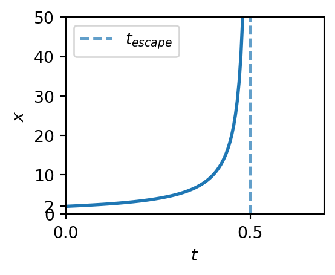

```python
import numpy as np
import matplotlib.pyplot as plt

x0 = 2
t_escape = 1/x0

t = np.linspace(0, t_escape-0.01, 100)
x = 1 / (1/x0 - t)

plt.figure(figsize=(3, 2.5))
plt.plot(t, x, linewidth=2)
plt.axvline(x=t_escape, linestyle='--', alpha=0.7, label='$t_{escape}$')
plt.xlabel(r'$t$')
plt.ylabel(r'$x$')
plt.xlim(0, t_escape + 0.2)
plt.ylim(0, 50)
plt.tight_layout()
plt.yticks([0, 10, 20, 30, 40, 50, x0])
plt.xticks([0, t_escape])
plt.legend()

plt.show()
```

For linear systems, $x(t) \to \infty$ cannot happen in finite time.

### 2. Multiple Isolated Equilibria

- Linear systems: either unique equilibrium or a continuum
- Pendulum: two isolated equilibria (one stable, one unstable)
- “Multi-stable” systems: two or more stable equilibria

**Example:** Bistable switch

$$\begin{array}{ll}
\dot x_1 = -ax_1 + x_2 & \quad x_1: \text{ concentration of protein} \\
\dot x_2 = \frac{x_1^2}{1 + x_1^2} -b x_2 & \quad x_2: \text{ concentration of mRNA}
\end{array}$$

$a>0$, $b>0$ are constants. State space: $\mathbb{R}_{\ge 0} \times \mathbb{R}_{\ge 0}$.

This model describes a positive feedback where the protein encoded by a gene stimulates more transcription via the term $\frac{x_1^2}{1 + x_1^2}$.

Single equilibrium at the origin when $ab>0.5$. If $ab<0.5$, the line where $\dot{x}_1=0$ intersects the sigmoidal curve where $\dot{x}_2=0$ at two other points, giving rise to a total of three equilibria:

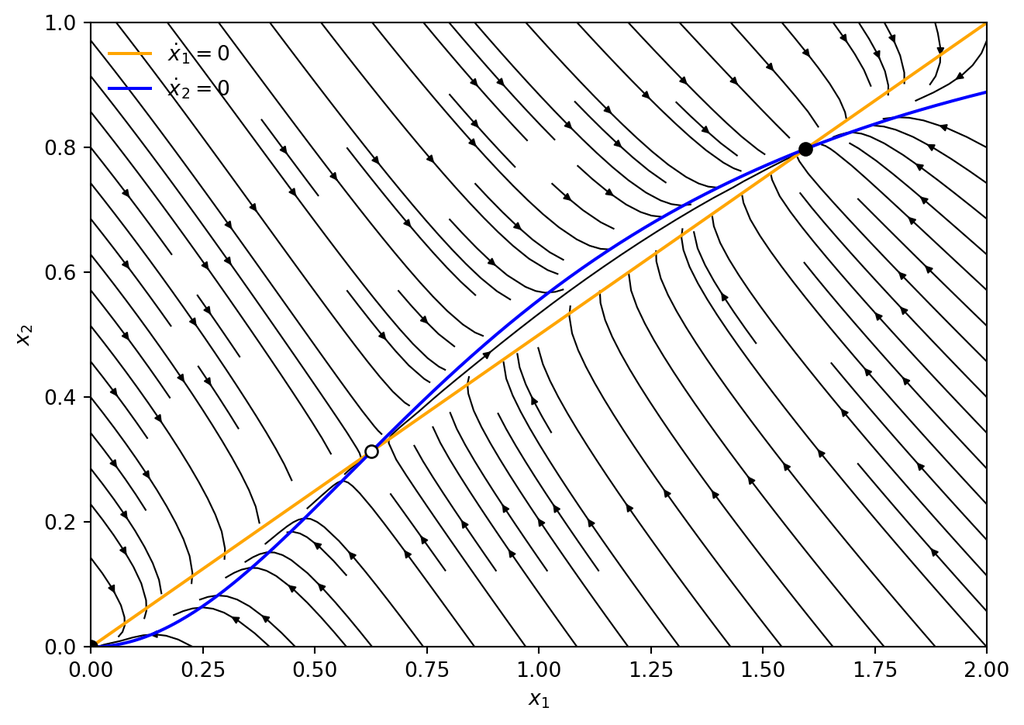

```python
import numpy as np
import matplotlib.pyplot as plt

a = 0.5
b = 0.9

# Grid
x1 = np.linspace(0, 2, 200)
x2 = np.linspace(0, 1, 200)
X1, X2 = np.meshgrid(x1, x2)

U = -a*X1 + X2
V = (X1**2)/(1 + X1**2) - b*X2

# Equilibria
disc = np.sqrt(1 - 4*a**2*b**2)
x1_minus = (1 - disc)/(2*a*b)
x1_plus  = (1 + disc)/(2*a*b)

eq_stable_low  = (0, 0)
eq_saddle      = (x1_minus, a*x1_minus)
eq_stable_high = (x1_plus,  a*x1_plus)

# Plot streamlines
plt.streamplot(
    X1, X2, U, V,
    density=1.2,
    linewidth=0.8,
    arrowsize=0.7,
    color='black'
)

# Nullclines
x = np.linspace(0, 2.2, 400)
plt.plot(x, a*x, color='orange', lw=1.5, label=r'$\dot x_1=0$')
plt.plot(x, x**2/(b*(1+x**2)), color='blue', lw=1.5, label=r'$\dot x_2=0$')

# Equilibria
plt.plot(*eq_stable_low,  'ko', ms=6)
plt.plot(*eq_saddle,      'ko', ms=6, mfc='white')
plt.plot(*eq_stable_high, 'ko', ms=6)

# Axes
plt.xlabel(r'$x_1$')
plt.ylabel(r'$x_2$')
plt.xlim(0, 2)
plt.ylim(0, 1)
plt.legend(frameon=False)
plt.tight_layout()
plt.show()
```

**Intuitive Interpretation:**

This system admits up to three equilibrium points, corresponding to distinct gene expression states.

The equilibrium at $(x_1, x_2) = (0, 0)$ represents a **gene-off state**, in which neither protein nor mRNA is present. Small perturbations away from this state decay back to zero: insufficient protein leads to insufficient transcription, and the system relaxes to silence. This equilibrium is therefore **stable**.

A second equilibrium appears at an intermediate protein and mRNA level. This equilibrium is **unstable (a saddle)** and acts as a **threshold** between gene-off and gene-on behavior. Initial conditions on one side of this point decay toward the off state, while those on the other side are amplified toward sustained expression. Biologically, this corresponds to a critical protein concentration required to maintain transcriptional activity.

The third equilibrium corresponds to a **gene-on state**, with high protein and mRNA concentrations. Here, positive feedback between protein abundance and transcription balances degradation, leading to persistent expression. Small perturbations around this point decay, making it a **stable high-expression state**.

Together, these equilibria give rise to **bistability**: the system can settle into either a low-expression or high-expression state depending on initial conditions, with the unstable equilibrium defining the boundary between their basins of attraction.

### 3. Limit Cycles

Linear oscillators exhibit a continuum of periodic orbits; *e.g.*, every circle is a periodic orbit for $\dot{x}=Ax$ where

$$A = \begin{bmatrix}0 & -\beta \\ \beta & 0\end{bmatrix} \quad (\lambda_{1, 2} = \mp j\beta).$$

In contrast, a limit cycle is an isolated periodic orbit and can occur only in nonlinear systems.

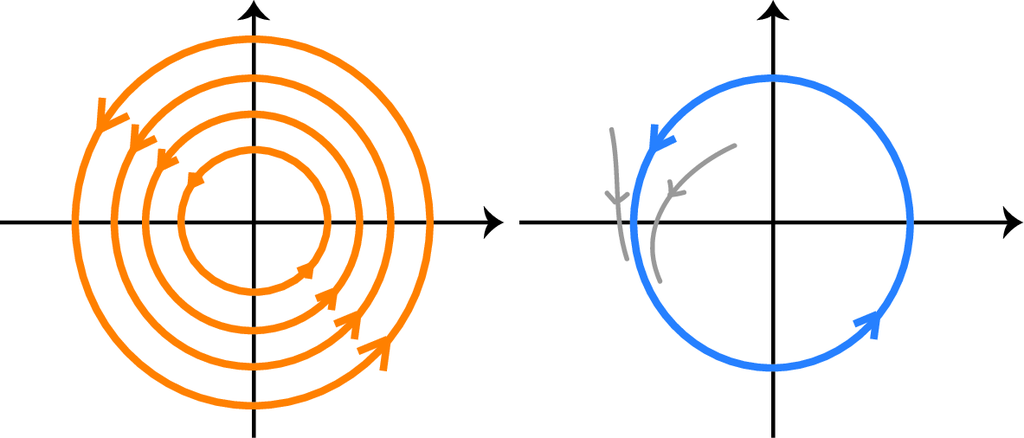

Harmonic oscillator vs. limit cycle

$v_C(t)$: the voltage across the capacitor (representing stored electric energy)

$i_L(t)$: the current through the inductor (representing stored magnetic energy).

$C$: parameter of capacitor

$L$: parameter of inductor

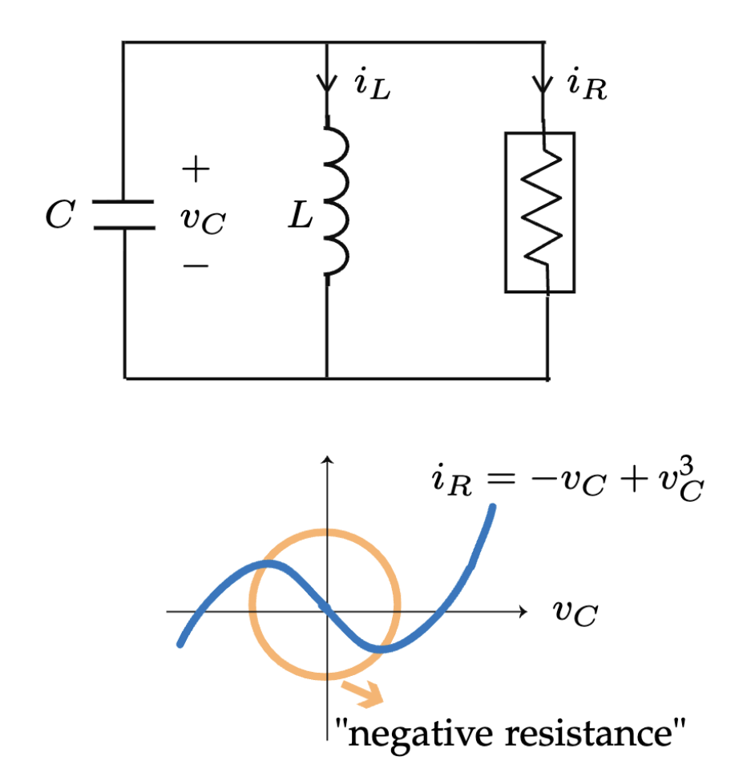

Van der Pol circuit

**Example:** Van der Pol oscillator (models a system with self-sustained oscillations)

$$\begin{aligned}
C \dot v_C &= -i_L + v_C - v_C^3 \\
L \dot i_L &= v_C
\end{aligned}$$

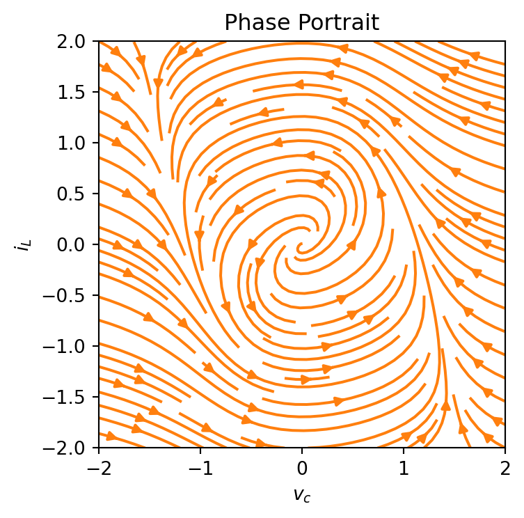

Van der Pol Oscillator Phase Portrait (nonlinear, isolated limit cycle).

```python
import numpy as np
import matplotlib.pyplot as plt

fig, ax = plt.subplots(figsize=(10, 4))

x = np.linspace(-2, 2, 200)
y = np.linspace(-2, 2, 200)
X, Y = np.meshgrid(x, y)

# Van der Pol Oscillator vector field
C = 1.0
L = 1.0
U = (1/C) * (-Y + X - X**3)
V = (1/L) * X

ax.streamplot(X, Y, U, V, color='C1', density=1.2)
ax.set_title("Phase Portrait")
ax.set_xlabel(r"$v_c$")
ax.set_ylabel(r"$i_L$")
ax.set_aspect('equal')
ax.set_xlim(-2, 2)
ax.set_ylim(-2, 2)

plt.tight_layout()
plt.show()
```

### 4. Chaos

Irregular oscillations, never exactly repeating.

**Example:** Lorenz system (derived by Ed Lorenz in 1963 as a simplified model of convection rolls in the atmosphere):

$$\begin{aligned}
\dot x &= \sigma(y - x) \\
\dot y &= rx - y - xz \\
\dot z &= xy - bz
\end{aligned}$$

Chaotic behavior with $\sigma = 10$, $b = 8/3$, $r = 28$:

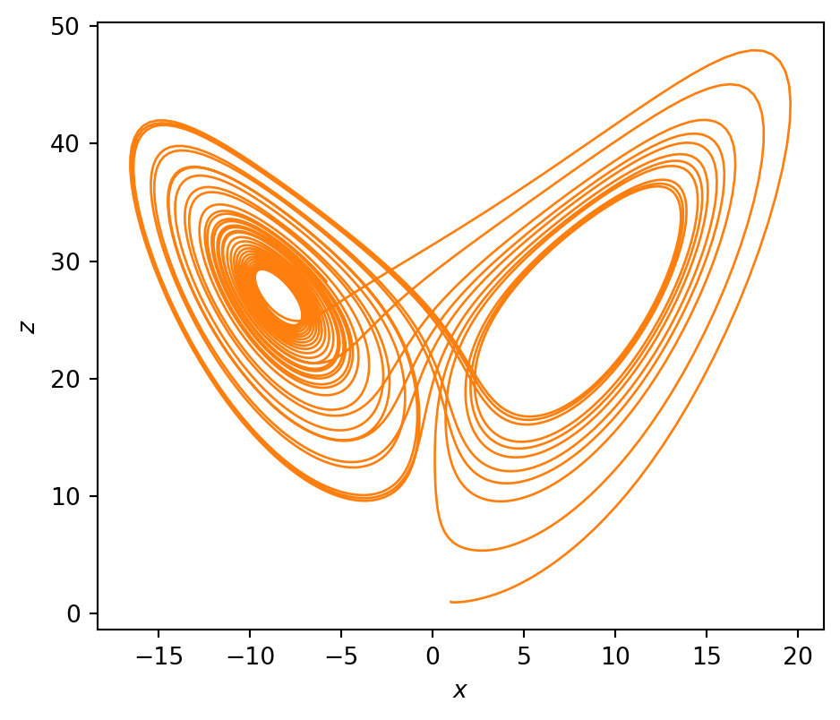

Lorenz system: 2D projection.

```python
import numpy as np
import matplotlib.pyplot as plt
from scipy.integrate import solve_ivp

# Lorenz system parameters
sigma = 10.0
b = 8/3
r = 28.0

def lorenz(t, X):
  x, y, z = X
  dx = sigma * (y - x)
  dy = r * x - y - x * z
  dz = x * y - b * z
  return [dx, dy, dz]

# Initial condition and time span
X0 = [1.0, 1.0, 1.0]
t_span = (0, 30)
t_eval = np.linspace(*t_span, 5000)

sol = solve_ivp(lorenz, t_span, X0, t_eval=t_eval)

# Create figure and axes explicitly
fig = plt.figure(figsize=(5, 8))

# 2D projection (x vs z)
ax2d = fig.add_subplot(2, 1, 2)
ax2d.plot(sol.y[0], sol.y[2], color='C1', lw=1)
ax2d.set_xlabel('$x$')
ax2d.set_ylabel('$z$')

plt.tight_layout()
plt.show()
```

```python
import numpy as np
import plotly.graph_objects as go
from scipy.integrate import solve_ivp

# Lorenz system
sigma, b, r = 10.0, 8/3, 28.0

def lorenz(t, X):
    x, y, z = X
    return [
        sigma * (y - x),
        r * x - y - x * z,
        x * y - b * z
    ]

# Solve system
sol = solve_ivp(
    lorenz,
    (0, 30),
    [1, 1, 1],
    t_eval=np.linspace(0, 30, 2000)
)

# Create animated frames
frames = [
    go.Frame(
        data=[go.Scatter3d(
            x=sol.y[0][:k],
            y=sol.y[1][:k],
            z=sol.y[2][:k],
            mode="lines",
            line=dict(color="royalblue", width=4)
        )]
    )
    for k in range(10, len(sol.y[0]), 20)
]

fig = go.Figure(
    data=frames[0].data,
    frames=frames
)

fig.update_layout(
    scene=dict(
        xaxis=dict(title='x', range=[-30, 30]),
        yaxis=dict(title='y', range=[-30, 30]),
        zaxis=dict(title='z', range=[0, 50])
    ),
    updatemenus=[{
        "type": "buttons",
        "buttons": [{
            "label": "Play",
            "method": "animate",
            "args": [None, {"frame": {"duration": 30}, "fromcurrent": True}]
        }]
    }]
)

fig
```

[interactive chart not shown]

**Key observations:**

- For continuous-time, time-invariant systems, $n \ge 3$ state variables required for chaos.
  - For $n = 1$: $x(t)$ is monotone in $t$, so no oscillations are possible.

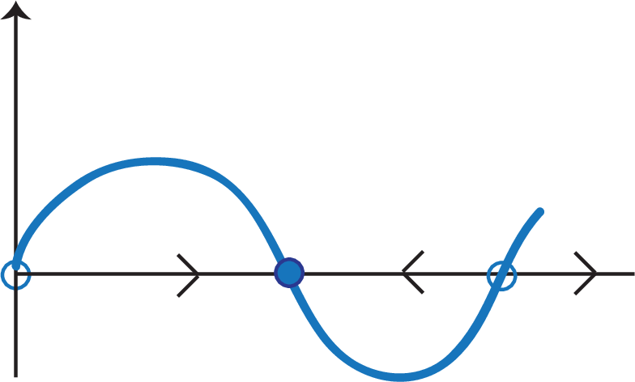

  - For $n = 2$: The Poincaré-Bendixson Theorem (to be studied in Lecture 4) guarantees regular (non-chaotic) behavior.
  - Poincaré-Bendixson does not apply to time-varying systems, and $n \ge 2$ is enough for chaos (e.g., Van der Pol oscillator can exhibit chaos).
  - For discrete-time systems, $n = 1$ is enough for chaos (we will see an example in Lecture 6).

### 5. Multiple Modes of Behavior

Hybrid systems exhibit both continuous and discrete dynamics. Examples include a bouncing ball, or a legged robot.

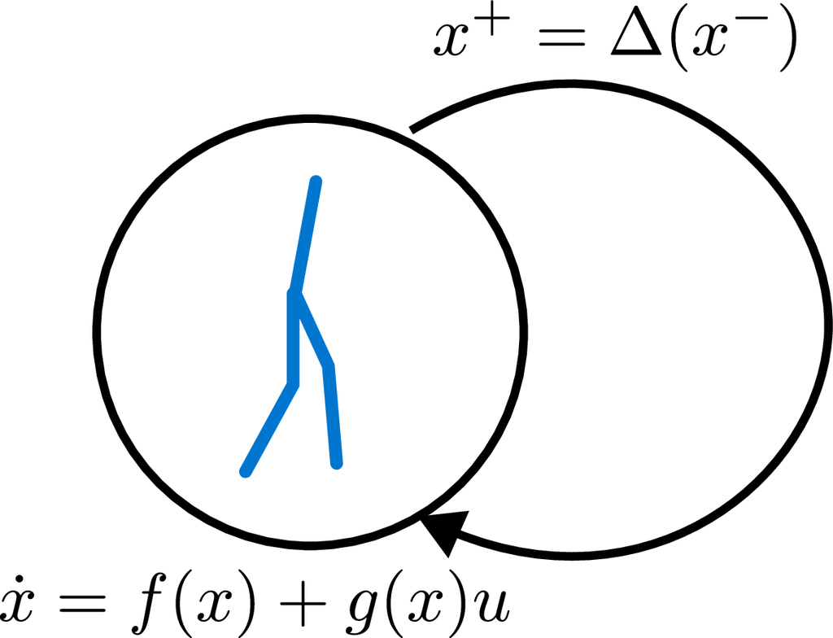

Hybrid system

## Planar (Second Order) Dynamical Systems

Chapter 2 in both Sastry and Khalil

$$\begin{aligned}
\dot x_1 &= f_1(x_1, x_2) \\
\dot x_2 &= f_2(x_1, x_2)
\end{aligned}$$

Second-order autonomous systems are convenient to study because solution trajectories (i.e., $x(t) = x_1(t), x_2(t)$) can be represented as curves in the plane. This “plane” is usually called the *phase plane* with $f(x)$ the *vector field* on the phase plane.

The family of all trajectories (solution curves) is called the *phase portrait* of the system. For example, recall that the phase portrait of the pendulum system was:

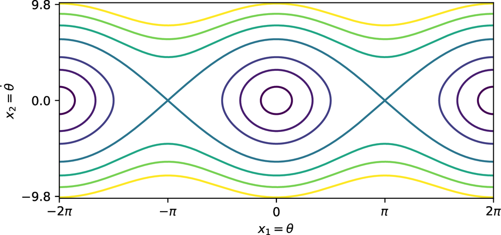

Pendulum phase portrait

### Phase Portraits of Linear Systems: $\dot x = A x$

Depending on the eigenvalues of $A$, the real Jordan form $J = T^{-1} A T$ has one of three forms:

#### Distinct real eigenvalues

$$T^{-1}A T = \begin{bmatrix} \lambda_1 & 0 \\ 0 & \lambda_2 \end{bmatrix}$$

In $z = T^{-1} x$ coordinates:

$$\dot z_1 = \lambda_1 z_1, \quad \dot z_2 = \lambda_2 z_2$$

The equilibrium is called a *node* when $\lambda_1$ and $\lambda_2$ have the same sign (*stable* node when negative and *unstable* when positive). It is called a *saddle point* when $\lambda_1$ and $\lambda_2$ have opposite signs.

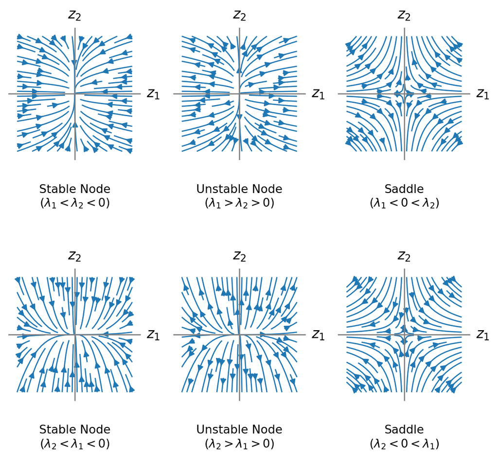

Phase portraits for different eigenvalue configurations with $\lambda_1$, $\lambda_2$ being distinct and real

```python
import numpy as np
import matplotlib.pyplot as plt

def plot_linear_phase(ax, A, title, color='C0'):
  x = np.linspace(-2, 2, 20)
  y = np.linspace(-2, 2, 20)
  X, Y = np.meshgrid(x, y)
  U = A[0,0]*X + A[0,1]*Y
  V = A[1,0]*X + A[1,1]*Y
  ax.streamplot(X, Y, U, V, color=color, density=0.8, linewidth=1)
  # Move title below the plot
  ax.set_title("", fontsize=10)  # Remove default title
  ax.text(0.5, -0.18, title, fontsize=10, ha='center', va='top', transform=ax.transAxes)
  ax.set_xticks([])
  ax.set_yticks([])
  ax.set_xlim(-2.3, 2.3)
  ax.set_ylim(-2.3, 2.3)
  ax.set_aspect('equal')

  # Remove plot border/spines
  for spine in ax.spines.values():
      spine.set_visible(False)

  # Draw axes at x=0 and y=0
  ax.axhline(0, color='gray', linewidth=1)
  ax.axvline(0, color='gray', linewidth=1)

  # Add axis labels at the ends
  ax.text(2.5, 0, r"$z_1$", va='center', ha='left', fontsize=12)
  ax.text(0, 2.5, r"$z_2$", va='bottom', ha='center', fontsize=12)

fig, axes = plt.subplots(2, 3, figsize=(6, 6))

# 1. Stable node: lambda1 < lambda2 < 0
fast_lambda, slow_lambda = 1.5, 0.5
A1 = np.array([[-fast_lambda, 0], [0, -slow_lambda]])
plot_linear_phase(axes[0, 0], A1, "Stable Node\n($\\lambda_1 < \\lambda_2 < 0$)")

# 2. Unstable node: lambda1 > lambda2 > 0
A2 = np.array([[fast_lambda, 0], [0, slow_lambda]])
plot_linear_phase(axes[0, 1], A2, "Unstable Node\n($\\lambda_1 > \\lambda_2 > 0$)")

# 3. Saddles: lambda1 < 0 < lambda2
A3 = np.array([[-slow_lambda, 0], [0, slow_lambda]])
plot_linear_phase(axes[0, 2], A3, "Saddle\n($\\lambda_1 < 0 < \\lambda_2$)")

# 4. Stable node: lambda2 < lambda1 < 0
A4 = np.array([[-slow_lambda, 0], [0, -fast_lambda]])
plot_linear_phase(axes[1, 0], A4, "Stable Node\n$(\\lambda_2 < \\lambda_1 < 0$)")

# 5. Unstable node: lambda2 > lambda1 > 0
A5 = np.array([[slow_lambda, 0], [0, fast_lambda]])
plot_linear_phase(axes[1, 1], A5, "Unstable Node\n$(\\lambda_2 > \\lambda_1 > 0$)")

# 6. Saddles: lambda2 < 0 < lambda1
A6 = np.array([[slow_lambda, 0], [0, -slow_lambda]])
plot_linear_phase(axes[1, 2], A6, "Saddle\n($\\lambda_2 < 0 < \\lambda_1$)")


plt.tight_layout()
plt.show()
```

#### Complex eigenvalues: $\lambda_{1, 2} = \alpha \mp j\beta$

$$T^{-1}A T = \begin{bmatrix} \alpha & -\beta \\ \beta & \alpha \end{bmatrix}$$

$$\begin{aligned}
\dot z_1 &= \alpha z_1 - \beta z_2 \\
\dot z_2 &= \alpha z_2 + \beta z_1
\end{aligned}
\quad \rightarrow \quad \text{polar coordinates} \quad \rightarrow \quad
\begin{aligned}
\dot r &= \alpha r \\
\dot \theta &= \beta
\end{aligned}$$

The equilibrium is called a *focus* when $\lambda_1$ and $\lambda_2$ are complex with $\alpha \neq 0$ (*stable* when $\alpha < 0$ and *unstable* when $\alpha > 0$). It is called a *center* when $\alpha = 0$.

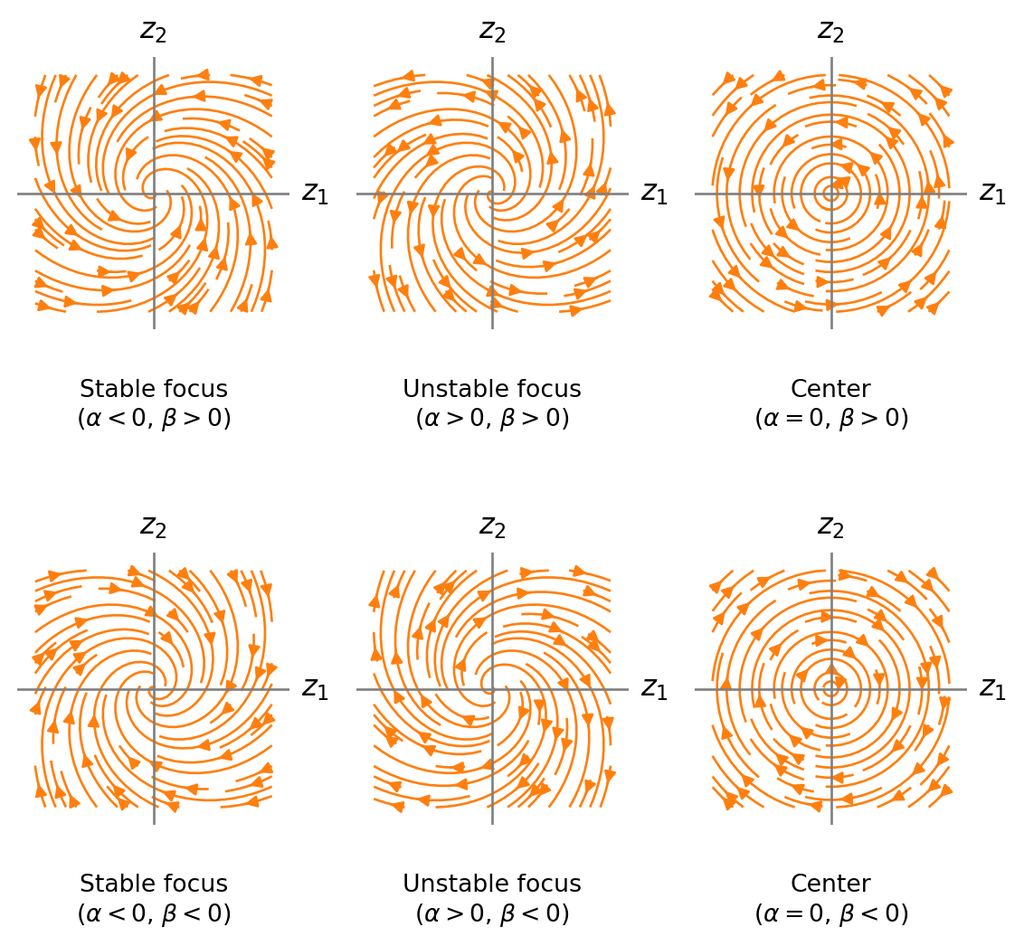

Phase portraits for different eigenvalue configurations with $\lambda_1$, $\lambda_2$ being complex conjugates

```python
import numpy as np
import matplotlib.pyplot as plt

def plot_linear_phase(ax, A, title, color='C1'):
  x = np.linspace(-2, 2, 20)
  y = np.linspace(-2, 2, 20)
  X, Y = np.meshgrid(x, y)
  U = A[0,0]*X + A[0,1]*Y
  V = A[1,0]*X + A[1,1]*Y
  ax.streamplot(X, Y, U, V, color=color, density=0.8, linewidth=1)
  # Move title below the plot
  ax.set_title("", fontsize=10)  # Remove default title
  ax.text(0.5, -0.18, title, fontsize=10, ha='center', va='top', transform=ax.transAxes)
  ax.set_xticks([])
  ax.set_yticks([])
  ax.set_xlim(-2.3, 2.3)
  ax.set_ylim(-2.3, 2.3)
  ax.set_aspect('equal')

  # Remove plot border/spines
  for spine in ax.spines.values():
      spine.set_visible(False)

  # Draw axes at x=0 and y=0
  ax.axhline(0, color='gray', linewidth=1)
  ax.axvline(0, color='gray', linewidth=1)

  # Add axis labels at the ends
  ax.text(2.5, 0, r"$z_1$", va='center', ha='left', fontsize=12)
  ax.text(0, 2.5, r"$z_2$", va='bottom', ha='center', fontsize=12)

fig, axes = plt.subplots(2, 3, figsize=(6, 6))

alpha, beta = 0.5, 1

# 1. Stable Focus, counter clockwise
A1 = np.array([[-alpha, -beta], [beta, -alpha]])
plot_linear_phase(axes[0, 0], A1, "Stable focus\n($\\alpha<0$, $\\beta>0$)")

# 2. Unstable Focus, counter clockwise
A2 = np.array([[alpha, -beta], [beta, alpha]])
plot_linear_phase(axes[0, 1], A2, "Unstable focus\n($\\alpha>0$, $\\beta>0$)")

# 3. Center, counter clockwise
A3 = np.array([[0, -beta], [beta, 0]])
plot_linear_phase(axes[0, 2], A3, "Center\n($\\alpha=0$, $\\beta>0$)")

# 4. Stable Focus, clockwise
A4 = np.array([[-alpha, beta], [-beta, -alpha]])
plot_linear_phase(axes[1, 0], A4, "Stable focus\n($\\alpha<0$, $\\beta<0$)")

# 5. Unstable Focus, clockwise
A5 = np.array([[alpha, beta], [-beta, alpha]])
plot_linear_phase(axes[1, 1], A5, "Unstable focus\n($\\alpha>0$, $\\beta<0$)")

# 6. Center, clockwise
A6 = np.array([[0, beta], [-beta, 0]])
plot_linear_phase(axes[1, 2], A6, "Center\n($\\alpha=0$, $\\beta<0$)")


plt.tight_layout()
plt.show()
```